# S6_informe

22 de Noviembre del 2022

##### Libreria a utlizar

```r
# Librerias a cargar
if (!require(stringr)){install.packages(stringr);library(stringr)}
if (!require(tidyverse)){install.packages(tidyverse);library(tidyverse)}
```

```r
if (!require(tidyr)){install.packages(tidyr);library(tidyr)}
if (!require(lubridate)){install.packages(lubridate);library(lubridate)}

if (!require(readr)){install.packages(readr);library(readr)}
if (!require(dplyr)){install.packages(dplyr);library(dplyr)}
if (!require(ggplot2)){install.packages(ggplot2);library(ggplot2)}
```

# Introduccion

Se hizo una recoleccion de datos a traves de una encuesta realizada a traves de google forms ([Enlace de la encuesta virtual](https://forms.gle/fYQEr8hcK6j76DfHA)) en la que se busca determinar la veracidad de distintas hipotesis acerca de la independencia familiar entre los estudiantes UTEC, haciendo comparaciones entre los estudiantes que viven de manera independiente y aquellos que no, asi tambien hacer analisis entre las variables de los datos recolectados. A su vez, este estudio estadistico puede ser de gran interes para analisis posteriores en materia de investigacion concerniente a los estudiantes de la Universidad de Ingenieria y Tecnologia - UTEC.

A su vez el presente informe de estudio de investigacion es de tipo transversal correlacional, el cual tiene un diseño de investigación no experimental.

## Objetivo:

Determinar la relacion entre la independencia familiar y el resto de variables, realizando multiples cuadros comparativos interpretando y analizando el comportamiento de estas relaciones con los estudiantes que aun no viven de manera independiente, todo esto a traves de la base de datos.

Para ello, definimos los siguientes objetivos específicos:

### Objetivos específicos:

- Determinar los modelos probabilísticos que describen la relación entre las variables.
- Hallar las probabilidades de los casos supuestos en base a nuestra muestra y variables.
- Analizar los datos de las variables, para encontrar datos atípicos y limpiar nuestra base de datos para no arrastrar errores.

## Planificación General

Para realizar este trabajo, se dividió las tareas de la siguiente manera:

### Diagrama de Gantt

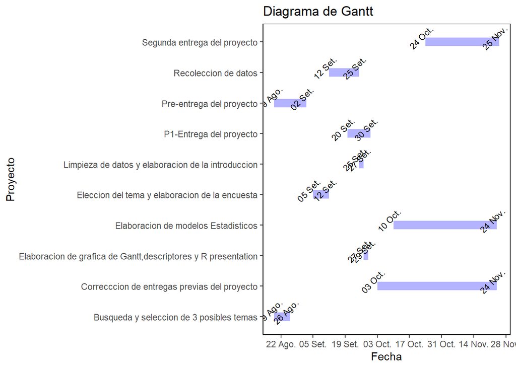

# Datos

La recolección de datos se realizó mediante un tipo de muestreo no probabilístico por conveniencia, debido a que realizamos una encuesta a través de google forms, la cual se envió por sitios de difusión masiva como grupos de WhatsApp, Telegram y Discord, cabe destacar que la encuesta realizada fue exclusiva para los estudiantes de UTEC

Se tomó esta forma de recolección de datos, debido a que de esta forma la obtención de la muestra es la más rápida.  
A su vez, cabe señalar que uno de los principales obstáculos al realizar la recolección de datos, fue la dificultad de poder llegar a los 200 alumnos encuestados de la UTEC. No obstante, planteamos estrategias que nos ayudaron a superar este problema, tales como ampliar el tiempo de recolección de datos, un pequeño sorteo a los que respondieran la encuesta y recolección de datos a estudiantes de manera presencial en la universidad, mostrándoles el código QR de nuestra encuesta.

## Población, muestra y muestreo

Nuestra población son todos los estudiantes de la universidad UTEC, en donde la unidad muestral son cada uno de los alumnos de la comunidad. El tamaño de la muestra es de 207 alumnos

## Base de Datos:

```r
data0 <- read_csv("dataframe.csv")
```

```
## -------------------------------------------------------- Delimiter: "," chr
## (15): Marca temporal, Sexo, Carrera, Procedencia, Residencia, Beca, Inde... dbl
## (20): Edad, Peso, Estatura, Edad_ingreso, Promedio, Promedio_acumulado, ... lgl
## (6): ...36, ...37, ...38, ...39, ...40, ...41
```

## Variables

VARIABLE

CLASE

TIPO

RESTRICCION

```
     DESCRIPCION
```

Beca

Categórica

Nominal

Alternativas consideradas

Hace referencia a si cuenta con algun tipo de beca

Carrera

Categórica

Nominal

Carreras UTEC

Hace referencia a la carrera que estudia

Causas

Categórica

Nominal

Alternativas consideradas

Hace referencia a las causa por las que cree que no se esta desenvolviendo bien este ciclo

Consumo menos frecuente

Categórica

Nominal

Alternativas consideradas

Referido al alimento del dia que con menor frecuencia consume durante un dia

Independencia

Categórica

Nominal

Si o No

Referido a si vive de manera independiente

Gastos comunes

Categórica

Nominal

Alternativas consideradas

Referido a los gastos que comunmente hace durante el mes

Motivo

Categórica

Nominal

Alternativas consideradas

Hace referencia al motivo de independencia

Org. Estudiantil

Categórica

Nominal

Alternativas consideradas

Hace referencia a si pertenece a alguna organizacion estudiantil en UTEC

Voluntariado

Categórica

Nominal

Alternativas consideradas

Hace referencia a si pertenece a alguna organizacion de voluntarios

Procedencia

Categórica

Nominal

Deptos. del Perú

Hace referencia al lugar de donde viene

Residencia

Categórica

Nominal

Distritos de Lima

Hace referencia al lugar donde vive actualmente

Sexo

Categórica

Nominal

Masculino o Femenino

Hace referencia a los componentes biológicos

Sociabilidad

Categórica

Nominal

Si o No

Referido al desenvolvimiento frente al resto

Amigos

Categórica

Ordinal

Escalas de Likert

Referido a la facilidad para conseguir amigos

Autoevaluación

Categórica

Ordinal

Escalas de Likert

Referido a como siente que le esta yendo

Ciclo

Categórica

Ordinal

I - X

Hace referencia al ciclo academico en el que se encuentra

Consumo saludable

Categórica

Ordinal

Escalas de Likert

Referido a la frecuencia de consumo de alimentos saludables y nutritivos

Problemas Académicos

Categórica

Ordinal

Escalas de Likert

Referido a la frecuencia con la que suele hablar con sus familiares sobre temas academicos

Problemas Económicos

Categórica

Ordinal

Escalas de Likert

Referido a la frecuencia con la que suele hablar con sus familiares sobre temas economicos

Problemas Emocionales

Categórica

Ordinal

Escalas de Likert

Referido a la frecuencia con la que suele hablar con sus familiares sobre temas emocionales

Estatura

Cuantitativa

Continua

Numero entero

Hace referencia a la altura en centimetros

Peso

Cuantitativa

Continua

Numero entero

Hace referencia al peso en kilogramos

Promedio

Cuantitativa

Continua

Número mayor a 0

Hace referencia a su promedio del ciclo anterior

Promedio Acumulado

Cuantitativa

Continua

Número mayor a 0

Hace referencia a su promedio general

Actividades extracurriculares

Cuantitativa

Discreta

Número entero

Referido al numero de horas que realiza actividades extracurriculares o de ocio

Ahorros

Cuantitativa

Discreta

Número Entero

Referido al dinero ahorrado al mes

Cursos Jalados

Cuantitativa

Discreta

Número Entero

Hace referencia a la cantidad de cursos jalados

Edad

Cuantitativa

Discreta

Numero entero

Hace referencia a la edad en años

Edad de Ingreso

Cuantitativa

Discreta

Número Entero

Hace referencia a la edad con la que ingreso a la universidad

Egresos

Cuantitativa

Discreta

Número Entero

Referido a la cantidad de dinero gasta al mes

Horas de estudio

Cuantitativa

Discreta

Número Entero

Referido a las horas que estudia fuera de clase

Horas familiares

Cuantitativa

Discreta

Número Entero

Referido al tiempo usado para comunicarse con sus familiares en la semana

Horas de sueño

Cuantitativa

Discreta

Número Entero

Referido a las horas que duerme normalmente

Ingresos

Cuantitativa

Discreta

Número Entero

Referido al dinero que percibe para subsistir durante el mes

## Limpieza de la base de datos

Para este proceso se consideró limpiar la base de datos de acuerdo a los siguiente puntos:

- Información irrelevante para el estudio.
- Datos incoherentes y confusos
- Tomar muy en cuenta que las repuestas ingresadas por parte de los encuestados vayan de acuerdo al tipo de variable requerido, esto con el fin de no tener problemas posteriores en el analisis de datos.

### Criterios de eliminacion de datos

- En esta investigación se hará un análisis variable por variable a través de barplot o boxplot para determinar y localizar si la variable es confusa o incoherente, teniendo en cuenta la pregunta planteada, debido a la segregación generada en la misma debido a factores tales como la pertenencia a un determinado ciclo y/o la de ser independiente o no

Posterior a todo ello se podria afirmar que la base de datos quedó “limpia” debido a que se pudo realizar un analisis objetivizado y sistematico en R el cual funcionó correctamente sin ningún problema de datos errados.

```
##  [1] "Marca temporal"     "Edad"               "Sexo"
##  [4] "Peso"               "Estatura"           "Carrera"
##  [7] "Procedencia"        "Residencia"         "Beca"
## [10] "Independiente"      "Motivo"             "Ciclo"
## [13] "Edad_ingreso"       "Org_est"            "Voluntariado"
## [16] "Promedio"           "Promedio_acumulado" "Cursos_jalados"
## [19] "Autoeval"           "Causas"             "Horas_est"
## [22] "Horas_sue"          "Alim_menor"         "Alim_nut"
## [25] "Extra"              "Amigos"             "Expres_pub"
## [28] "Horas_fam"          "Prob_acad"          "Prob_emo"
## [31] "Prob_eco"           "Ingreso"            "Gastos"
## [34] "din_gasto"          "din_ahorro"         "...36"
## [37] "...37"              "...38"              "...39"
## [40] "...40"              "...41"
```

La Marca temporal no tiene relevancia en este estudio, por ello se procede a eliminar la variable

```
##  [1] "Edad"               "Sexo"               "Peso"
##  [4] "Estatura"           "Carrera"            "Procedencia"
##  [7] "Residencia"         "Beca"               "Independiente"
## [10] "Motivo"             "Ciclo"              "Edad_ingreso"
## [13] "Org_est"            "Voluntariado"       "Promedio"
## [16] "Promedio_acumulado" "Cursos_jalados"     "Autoeval"
## [19] "Causas"             "Horas_est"          "Horas_sue"
## [22] "Alim_menor"         "Alim_nut"           "Extra"
## [25] "Amigos"             "Expres_pub"         "Horas_fam"
## [28] "Prob_acad"          "Prob_emo"           "Prob_eco"
## [31] "Ingreso"            "Gastos"             "din_gasto"
## [34] "din_ahorro"
```

```
## Tenemos 207 observaciones y 34 variables de la base de datos.
```

Ahora, se realiza la observación de casos incompletos.

```
## [1] 76
```

Se hace una observacion de los datos debido a que 76 de los datos totales estan incompletos

De lo anterior se vio que las personas que no se independizaron no se les permitió responder algunas de las preguntas del cuestionario, porque a criterio del grupo no serian relevantes, debido a que su respuesta seria perjudicial en la data, puesto que se pretende segregar la base de datos por distintas variables.  
Para confirmar esto recurriremos al siguiente gráfico para ver que tenemos una importante cantidad de personas que no viven de manera independiente

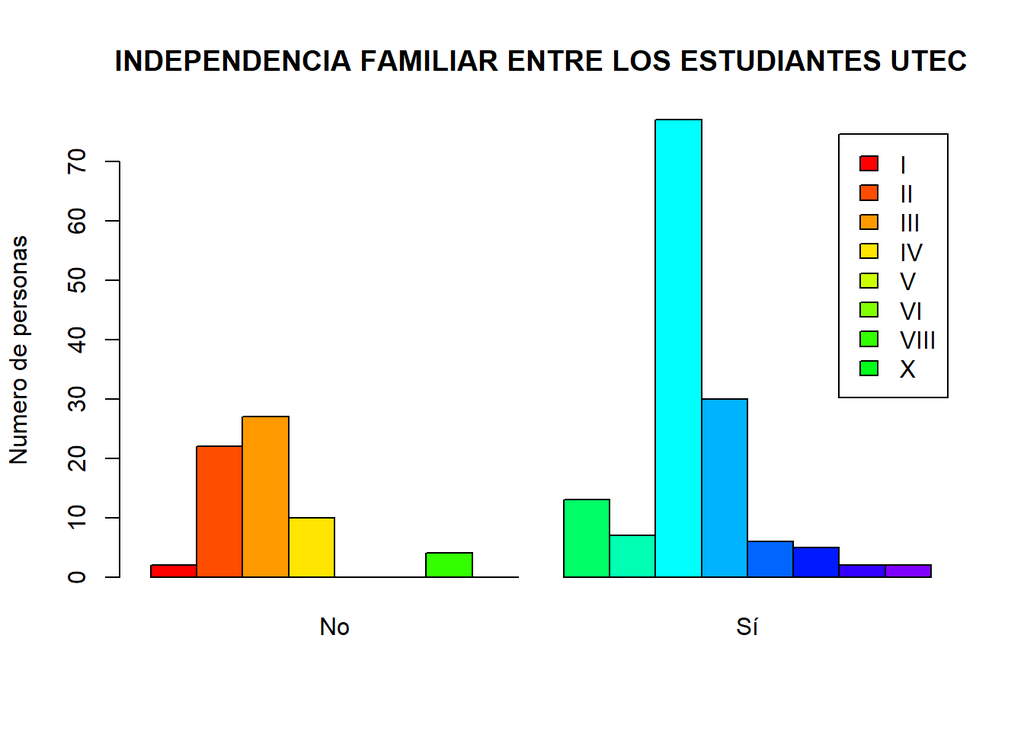

La gráfica demuestra que efectivamente hay una cantidad importante de personas que están entre las que no son independientes o pertenecen al ciclo I académico, este suceso se esperaba en nuestra base de datos, por lo cual realizamos nuestro plan de criterios de eliminación de datos.

Cabe resaltar que después de analizar esta gráfica, concluimos que nuestra muestra no es representativa, puesto que faltan unidades muestrales que representen a estudiantes que no son independientes de algunos ciclos. Además para el caso de estudiantes independientes los estudiantes de tercer ciclo son más numerosos, esto debido a que los integrantes en un principio recabaron información por medio de conexiones próximas a sí mismas y dado que el curso se lleva antes del quinto ciclo no es nada raro ver ese comportamiento.

## Descriptores Númericos

Según el resultado nuestras 207 encuestas son correctas. Sin embargo, no todos los datos son completos debido a que para este estudio se aplicaron restricciones frente a algunas preguntas a un grupo de estudiantes, tales como los no independientes y los estudiantes de primer ciclo. - funciones a usar:

```r
cv <- function(x, ...){
  return((sd(x, ...)/mean(x, ...))*100)
}
```

```r
r <- function(x){
    return(round(x,digits = 2)) #funcion para redondear a 2 decimales
}
```

```r
mode <- function(x) {
   return(as.numeric(names(which.max(table(x)))))
}
```

Determinamos si las variables tienen datos atípicos, con el fin de poder identificar las variables a las cuales podemos calcular sus descriptores numéricos y si cumplen condiciones, ya que en las gráficas de caja el símbolo * o ° identifica los valores atípicos. Estos valores atípicos son observaciones que están a por lo menos 1.5 veces el rango intercuartil (Q3 – Q1) del borde de la caja. en los cuales no sera viable calcular todos sus descriptores numéricos, por ello se hará un análisis interpretativo de las gráficas antes de calcular sus descriptores numéricos.

–> *Edad*

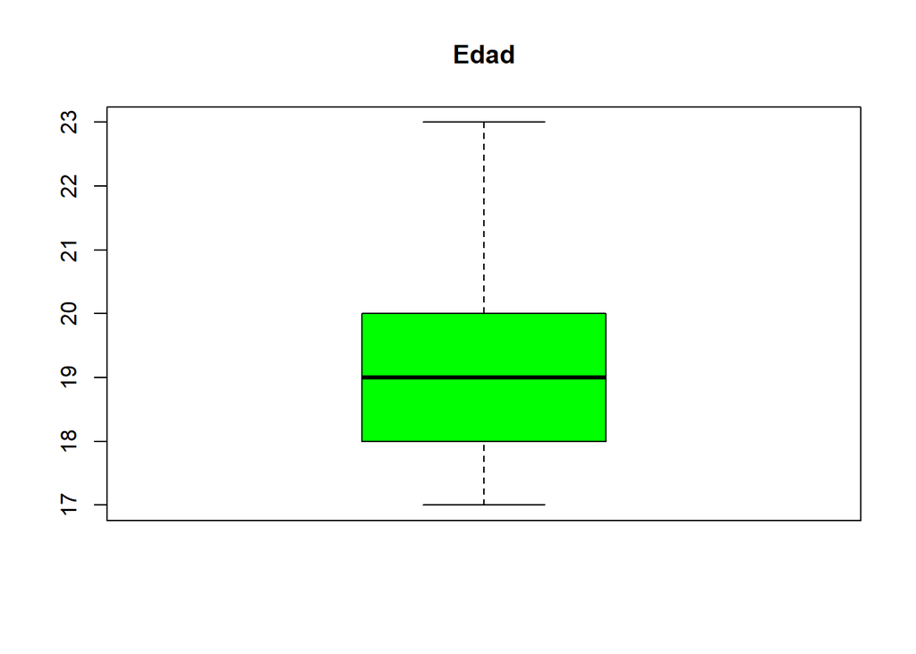

```r
boxplot(data0$Edad,
        main = "Edad",
        boxwex = 0.7,col="green")
```

No presenta datos atipicos  
*Descriptores de la variable edad:*

```
## Moda: 18
```

```
## Mediana: 19
```

```
## Desviación Estándar: 1.27
```

```
## Rango: 17 23
```

```
## Rango Intercuartílico: 2
```

```
## Coeficiente de Variación: 6.74
```

```
## Varianza: 1.63
```

```
##
##  Shapiro-Wilk normality test
##
## data:  data0$Edad
## W = 0.8948, p-value = 7.038e-11
```

Hay evidencia suficiente para decir que la muestra no proviene de una población con distribución normal.

–> *Estatura*

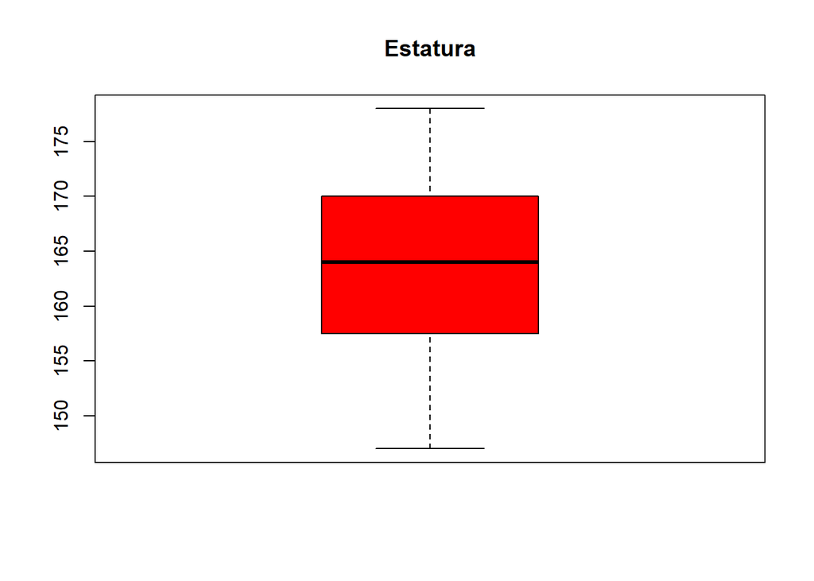

```r
boxplot(data0$Estatura,
        main = "Estatura",
        boxwex = 0.7,col="red")
```

No presenta datos atipicos  
*Descriptores de la variable Estatura:*

```
## Promedio: 163.29
```

```
## Mediana: 164
```

```
## Desviación Estándar: 7.89
```

```
## Rango: 147 178
```

```
## Rango Intercuartílico: 12.5
```

```
## Coeficiente de Variación: 4.83
```

```
## Varianza: 62.33
```

```
##
##  Shapiro-Wilk normality test
##
## data:  data0$Estatura
## W = 0.97251, p-value = 0.0004475
```

Hay evidencia suficiente para decir que la muestra no proviene de una población con distribución normal. –> *Peso*

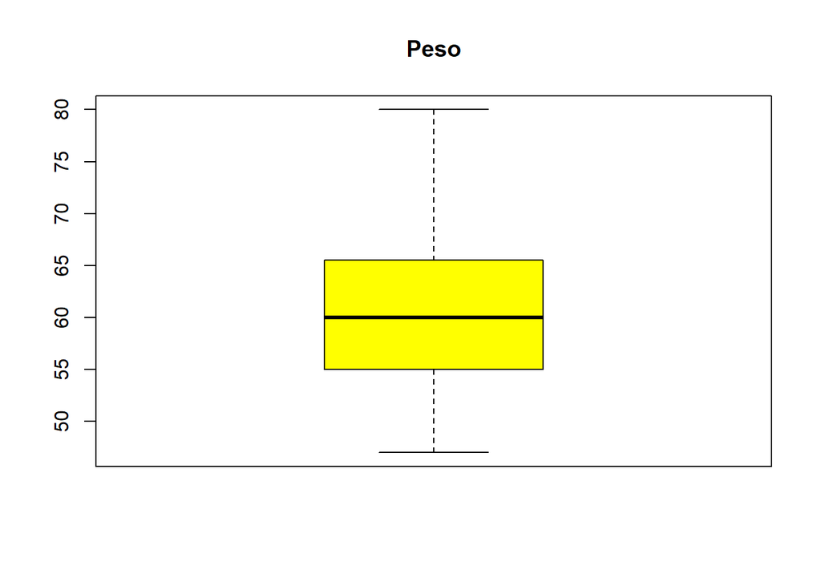

```r
boxplot(data0$Peso,
        main = "Peso",
        boxwex = 0.7,col="yellow")
```

No presenta datos atipicos  
*Descriptores de la variable Peso:*

```
## Promedio: 61.01
```

```
## Mediana: 60
```

```
## Desviación Estándar: 7.94
```

```
## Rango: 47 80
```

```
## Rango Intercuartílico: 10.5
```

```
## Coeficiente de Variación: 13.01
```

```
## Varianza: 62.99
```

```
##
##  Shapiro-Wilk normality test
##
## data:  data0$Peso
## W = 0.96886, p-value = 0.0001537
```

–> *Promedio de nota del ciclo anterior* En esta variable debemos tener cuidado, puesto que los estudiantes de 1er ciclo no tienen un promedio previo ni una nota acumulada a analizar con respecto a la UTEC

```r
prom1 <- data0
nrow(prom1) - sum(complete.cases(prom1))
```

```
## [1] 76
```

```r
prom1 <- na.omit(prom1) # eliminamos los N/A
```

identificamos los casos incompletos y los sacamos para obtener una nueva lista de datos de esta variable

```r
nrow(prom1) - sum(complete.cases(prom1)) # indica que tenemos casos incompletos
```

```
## [1] 0
```

```r
prom2<-select(prom1,"Promedio")
```

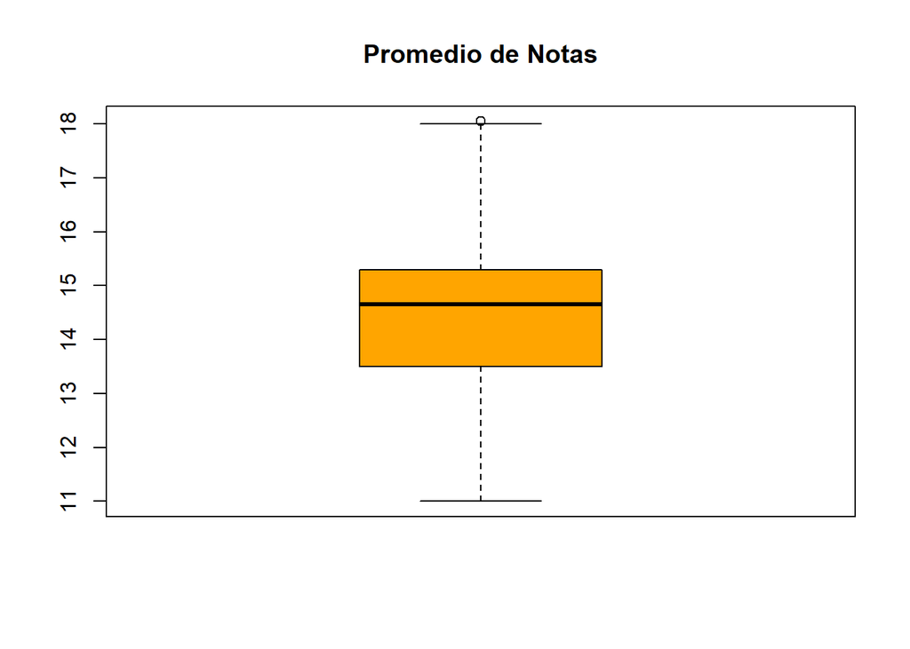

```r
boxplot(prom2$Promedio,
        main = "Promedio de Notas",
        boxwex = 0.7,col="orange")
```

*Descriptores de la variable Promedio:*

```
## Mediana: 14.66
```

```
## Desviación Estándar: 1.47
```

```
## Rango: 11 18.05
```

```
## Rango Intercuartílico: 1.8
```

```
## Coeficiente de Variación: 10.27
```

```
## Varianza: 2.18
```

–> *Promedio de notas acumulados de todos los ciclos*

En esta variable debemos tener cuidado, puesto que los estudiantes de 1er ciclo no tienen un promedio previo ni una nota acumulada a analizar con respecto a la UTEC, ademas los estudiantes de segundo deben ingresar el promedio acumulado igual al promedio del ciclo anterior, si esta condicion no se cumple, entonces esta variable se elimina por incoherencia entre sus datos. Esto debido a que representa a una importante cantidad de nuestra muestra

```r
muestra1 <- select(data0,"Promedio","Promedio_acumulado","Ciclo")
nrow(muestra1) - sum(complete.cases(muestra1))
```

```
## [1] 13
```

```r
muestra1 <- na.omit (muestra1) # eliminamos los N/A
```

identificamos los casos incompletos y los sacamos para obtener una nueva lista de datos de esta variable

```r
muestra <- muestra1[muestra1$Ciclo=="II",]
muestra
```

| Promedio | Promedio_acumulado | Ciclo |
| --- | --- | --- |
| 18.05 | 18.10 | II |
| 16.00 | 15.10 | II |
| 16.00 | 15.00 | II |
| 16.70 | 16.70 | II |
| 12.75 | 12.75 | II |
| 12.75 | 12.75 | II |
| 12.00 | 12.75 | II |
| 12.75 | 12.75 | II |
| 15.10 | 15.10 | II |
| 14.25 | 13.50 | II |

[output cut: 19 more lines]

En teoria si hacemos graficas de estas dos variables, deberian describir el mismo comportamiento en un boxplot, de no ser el caso se procedera a eliminar la variable de nuestra data principal

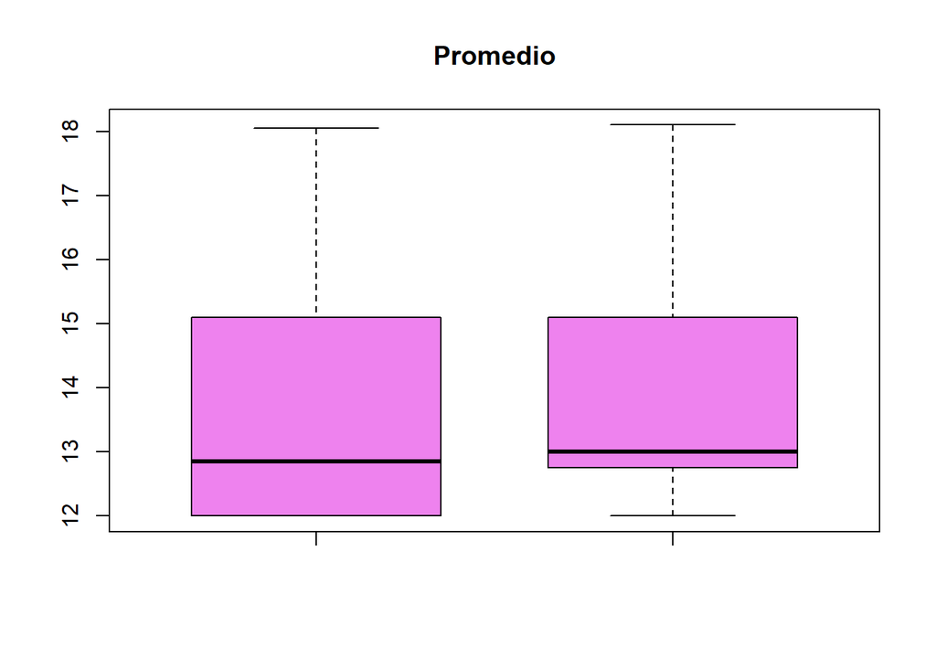

```r
boxplot(muestra$Promedio,muestra$Promedio_acumulado,
        main = "Promedio",
        boxwex = 0.7,col="violet")
```

Eliminamos el promedio acumulado por que es un dato que no coincide con promedio anterior

```r
data0<- select(data0, -"Promedio_acumulado")
names(data0)
```

```
##  [1] "Edad"           "Sexo"           "Peso"           "Estatura"
##  [5] "Carrera"        "Procedencia"    "Residencia"     "Beca"
##  [9] "Independiente"  "Motivo"         "Ciclo"          "Edad_ingreso"
## [13] "Org_est"        "Voluntariado"   "Promedio"       "Cursos_jalados"
## [17] "Autoeval"       "Causas"         "Horas_est"      "Horas_sue"
## [21] "Alim_menor"     "Alim_nut"       "Extra"          "Amigos"
## [25] "Expres_pub"     "Horas_fam"      "Prob_acad"      "Prob_emo"
## [29] "Prob_eco"       "Ingreso"        "Gastos"         "din_gasto"
## [33] "din_ahorro"
```

–> *Horas dedicadas a actividades extracurriculares en la semana*

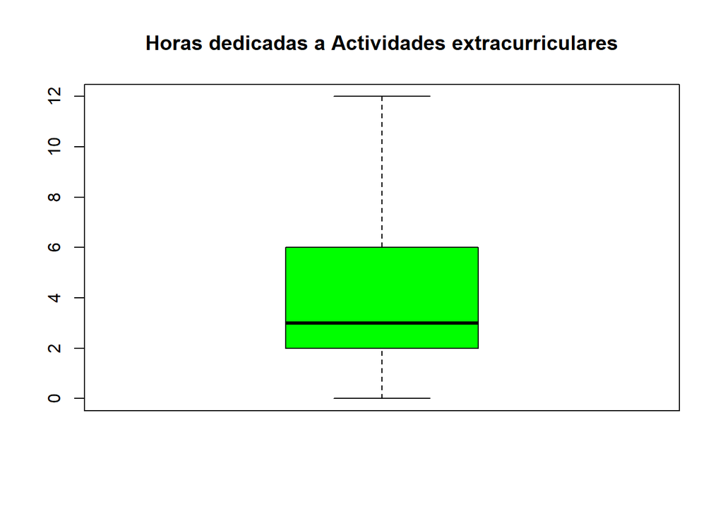

```r
boxplot(data0$Extra,
        main = "Horas dedicadas a Actividades extracurriculares",
        boxwex = 0.7,col="green")
```

No presenta datos atipicos  
*Descriptores de la variable Extra:*

```
## Promedio: 3.98
```

```
## Moda: 2
```

```
## Mediana: 3
```

```
## Desviación Estándar: 3.01
```

```
## Rango: 0 12
```

```
## Rango Intercuartílico: 4
```

```
## Coeficiente de Variación: 75.8
```

```
## Varianza: 9.08
```

–> *Dinero ahorrado a fin de mes*

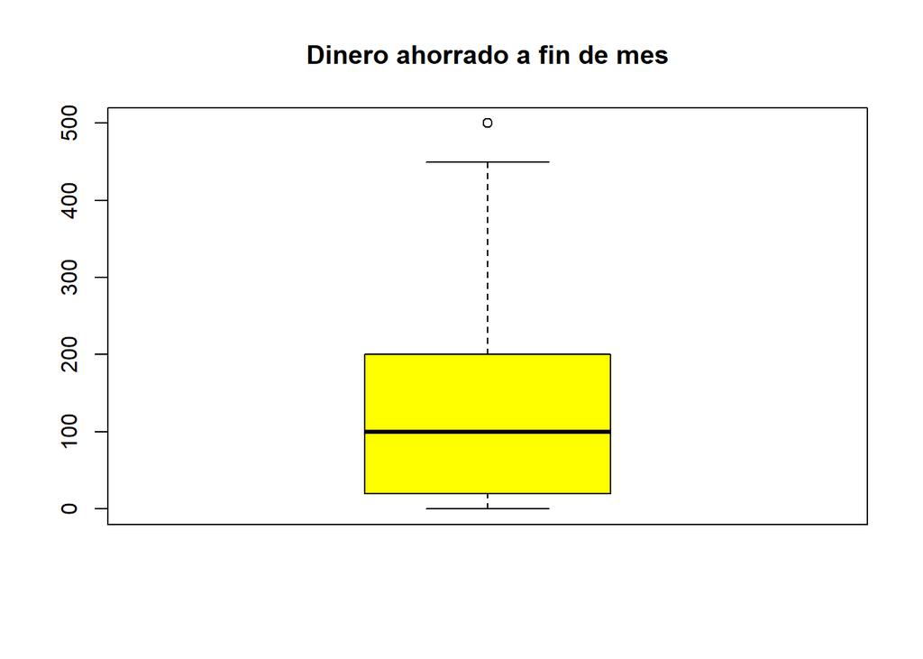

```r
boxplot(data0$din_ahorro,
        main = "Dinero ahorrado a fin de mes",
        boxwex = 0.7,col="yellow")
```

Si presenta datos atipicos *Descriptores de la variable din_ahorro:*

```
## Moda: 100
```

```
## Mediana: 100
```

```
## Desviación Estándar: 143.1
```

```
## Rango: 0 500
```

```
## Rango Intercuartílico: 180
```

```
## Coeficiente de Variación: 104.32
```

```
## Varianza: 20476.93
```

–> *Cursos jalados a lo largo de sus carrera* Esta variable al igual que la variables de Promedio acumulado no esta disponible para los de primer ciclo asi como esta variable no es posible analizarla debido a que depende del ciclo en el que se encuentre.

```r
data0<- select(data0, -"Cursos_jalados")
names(data0)
```

```
##  [1] "Edad"          "Sexo"          "Peso"          "Estatura"
##  [5] "Carrera"       "Procedencia"   "Residencia"    "Beca"
##  [9] "Independiente" "Motivo"        "Ciclo"         "Edad_ingreso"
## [13] "Org_est"       "Voluntariado"  "Promedio"      "Autoeval"
## [17] "Causas"        "Horas_est"     "Horas_sue"     "Alim_menor"
## [21] "Alim_nut"      "Extra"         "Amigos"        "Expres_pub"
## [25] "Horas_fam"     "Prob_acad"     "Prob_emo"      "Prob_eco"
## [29] "Ingreso"       "Gastos"        "din_gasto"     "din_ahorro"
```

–> *Edad de ingreso* Esta variable debido a que nuestra muestra no es representativa no nos va a ayudar con el estudio que realizamos, por lo tanto se elimina

```r
data0<- select(data0, -"Edad_ingreso")
names(data0)
```

```
##  [1] "Edad"          "Sexo"          "Peso"          "Estatura"
##  [5] "Carrera"       "Procedencia"   "Residencia"    "Beca"
##  [9] "Independiente" "Motivo"        "Ciclo"         "Org_est"
## [13] "Voluntariado"  "Promedio"      "Autoeval"      "Causas"
## [17] "Horas_est"     "Horas_sue"     "Alim_menor"    "Alim_nut"
## [21] "Extra"         "Amigos"        "Expres_pub"    "Horas_fam"
## [25] "Prob_acad"     "Prob_emo"      "Prob_eco"      "Ingreso"
## [29] "Gastos"        "din_gasto"     "din_ahorro"
```

–> *Cantidad de dinero gastado durante el mes*

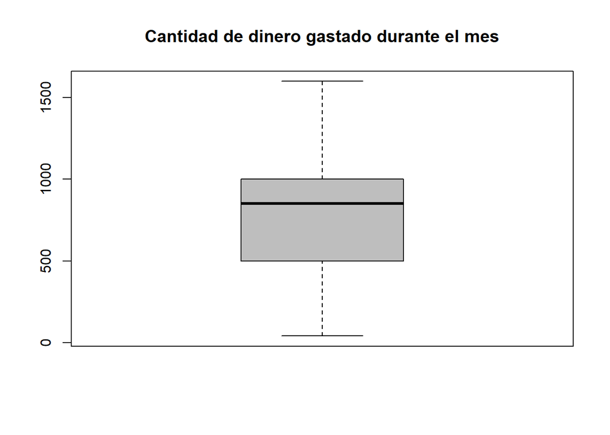

```r
boxplot(data0$din_gasto,
        main = "Cantidad de dinero gastado durante el mes",
        boxwex = 0.7,col="gray")
```

No presenta datos atipicos

*Descriptores de la variable dinero gastado durante el mes:*

```
## Media: 774.88
```

```
## Moda: 1000
```

```
## Mediana: 850
```

```
## Desviación Estándar: 364.6
```

```
## Rango: 40 1600
```

```
## Rango Intercuartílico: 500
```

```
## Coeficiente de Variación: 47.05
```

```
## Varianza: 132931.3
```

–> *Cantidad de horas que estudia durante el dia fuera de la horas de clases regulares*

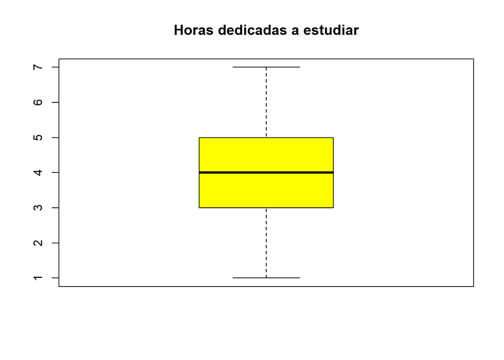

```r
boxplot(data0$Horas_est,
        main = "Horas dedicadas a estudiar",
        boxwex = 0.7,col="yellow")
```

No presenta datos atipicos  
*Descriptores de la variable horas que estudia durante el dia:*

```
## Media: 4.09
```

```
## Moda: 4
```

```
## Mediana: 4
```

```
## Desviación Estándar: 1.44
```

```
## Rango: 1 7
```

```
## Rango Intercuartílico: 2
```

```
## Coeficiente de Variación: 35.28
```

```
## Varianza: 2.08
```

–> *Cantidad de horas que duerme al dia regularmente*

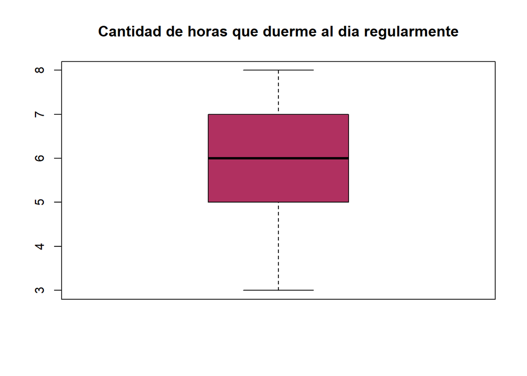

```r
boxplot(data0$Horas_sue,
        main = "Cantidad de horas que duerme al dia regularmente",
        boxwex = 0.7,col="maroon")
```

No presenta datos atipicos  
*Descriptores de la variable Horas de sueño:*

```
## Media: 5.97
```

```
## Moda: 6
```

```
## Mediana: 6
```

```
## Desviación Estándar: 1.12
```

```
## Rango: 3 8
```

```
## Rango Intercuartílico: 2
```

```
## Coeficiente de Variación: 18.74
```

```
## Varianza: 1.25
```

–> *Cantidad de horas que usa a la semana para comunicarse con su familia*

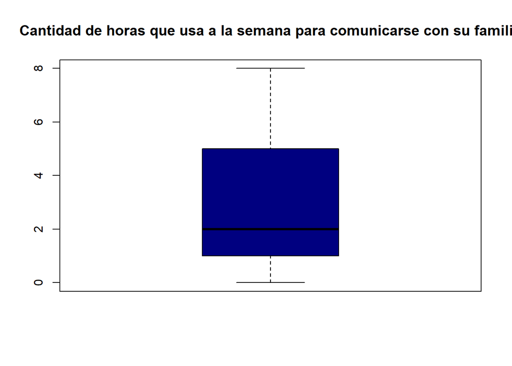

```r
boxplot(data0$Horas_fam,
        main = "Cantidad de horas que usa a la semana para comunicarse con su familia",
        boxwex = 0.7,col="navy")
```

No presenta datos atipicos  
*Descriptores de la variable Horas para comunicarse con su familia:*

```
## Media: 3.07
```

```
## Moda: 1
```

```
## Mediana: 2
```

```
## Desviación Estándar: 2.06
```

```
## Rango: 0 8
```

```
## Rango Intercuartílico: 4
```

```
## Coeficiente de Variación: 67.19
```

```
## Varianza: 4.26
```

–> *Ingresos mensuales del estudiante*

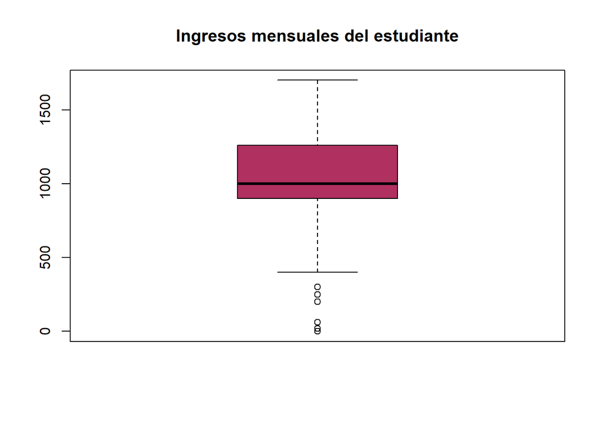

```r
boxplot(data0$Ingreso,
        main = "Ingresos mensuales del estudiante",
        boxwex = 0.7,col="maroon")
```

Si presenta datos atipicos

*Descriptores de la Ingresos mensuales del estudiante:*

```
## Moda: 1260
```

```
## Mediana: 1000
```

```
## Desviación Estándar: 421.6
```

```
## Rango: 0 1700
```

```
## Rango Intercuartílico: 360
```

```
## Coeficiente de Variación: 44.1
```

```
## Varianza: 177750.1
```

## Descriptores Gráficos

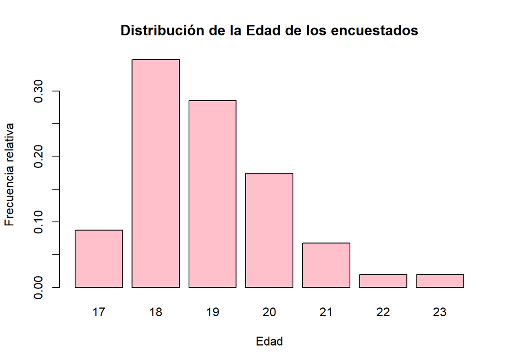

```r
tabla_edad=table(data0$Edad)
barplot(tabla_edad/nrow(data0),col = 'pink', main = "Distribución de la Edad de los encuestados", xlab = "Edad", ylab = "Frecuencia relativa")
```

En la gráfica se muestra la distribución de las personas encuestadas según su edad. Se encuestaron alumnos de 17 a 23 años aproximadamente. Se puede observar que la gráfica tiene un sesgo hacia la derecha por la cola larga en el lado derecho, y esto se confirma debido a que la mediana es menor que la media y por ello, se puede decir que la distribución es asimétrica. Interpretando la gráfica, nos podemos dar cuenta que hay una mayor cantidad de alumnos con 18 años y una minoría con 22 y 23 años. Considerando que la edad es una variable numérica discreta que va desde 0 hasta 98 aproximadamente y que nuestra muestra abarca de 17 a 23 se concluye que los datos son dispersos.

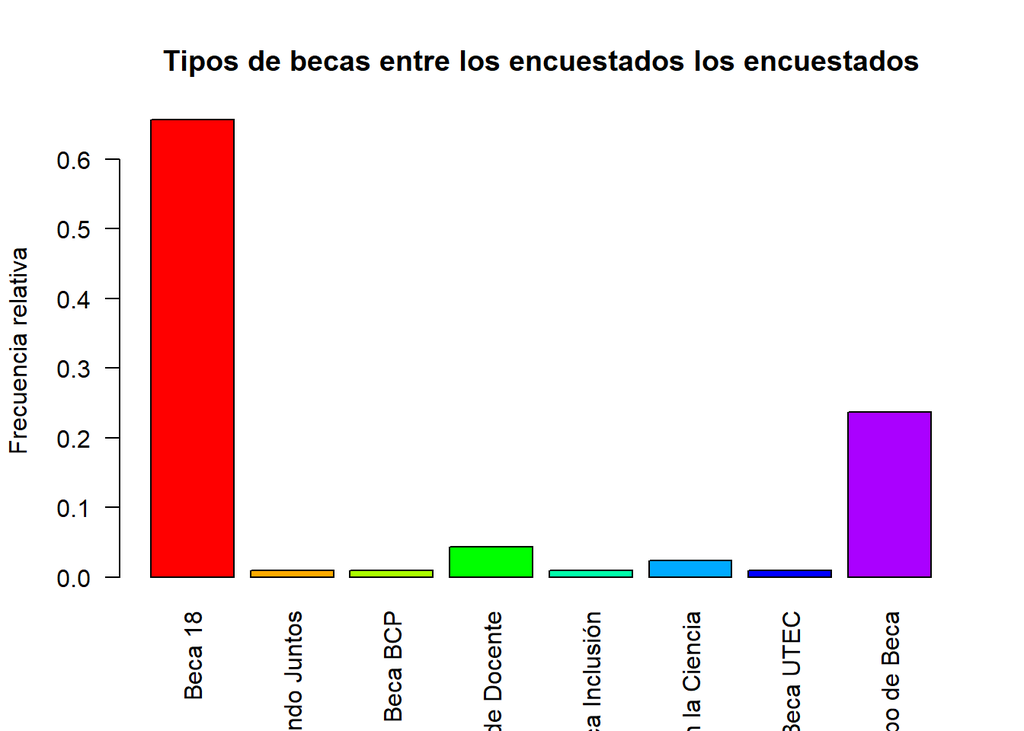

```r
tabla_Beca=table(data0$Beca)
barplot(tabla_Beca/nrow(data0),las=2,main="Tipos de becas entre los encuestados los encuestados", col=rainbow(9), ylab = "Frecuencia relativa")
```

La variable Tipo de beca, denota que una proporcion amayor respecto al resto de estudiantes con beca 18

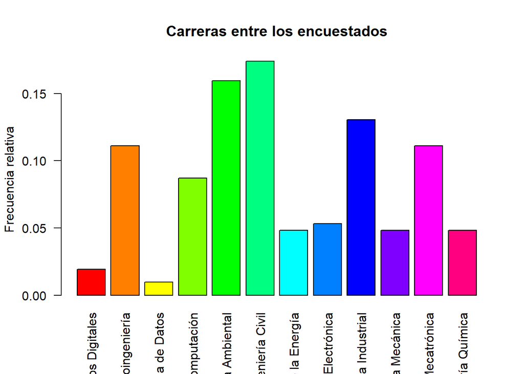

```r
tabla_Carrera=table(data0$Carrera)
barplot(tabla_Carrera/nrow(data0),las=2,main="Carreras entre los encuestados", col=rainbow(12), ylab = "Frecuencia relativa")
```

La grafica muestra las carreras que estudian los encuestados

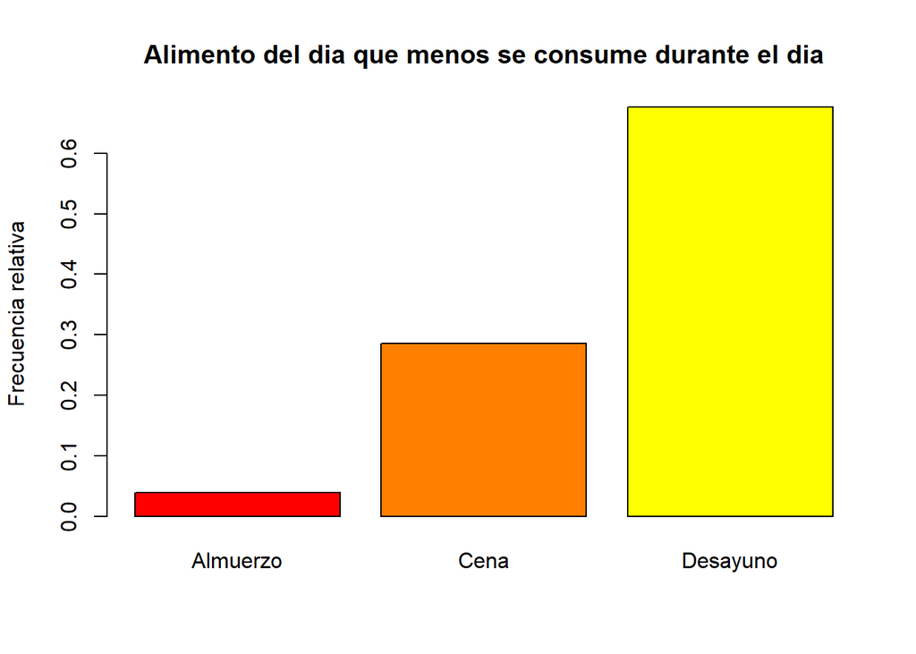

```r
tabla_Alim=table(data0$Alim_menor)
barplot(tabla_Alim/nrow(data0),main="Alimento del dia que menos se consume durante el dia", col=rainbow(12), ylab = "Frecuencia relativa")
```

Denota que los estudiantes UTEC ignoran con frecuencia el desayuno

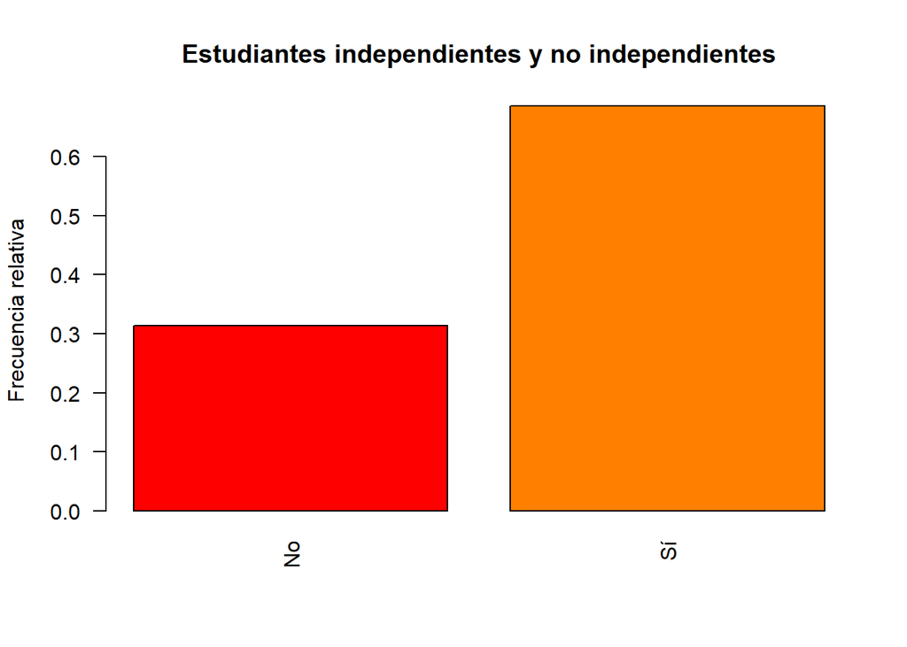

```r
tabla_Independiente=table(data0$Independiente)
barplot(tabla_Independiente/nrow(data0),las=2,main="Estudiantes independientes y no independientes", col=rainbow(12), ylab = "Frecuencia relativa")
```

En UTEC hay mas estudiantes independientes en relacion a los dependientes

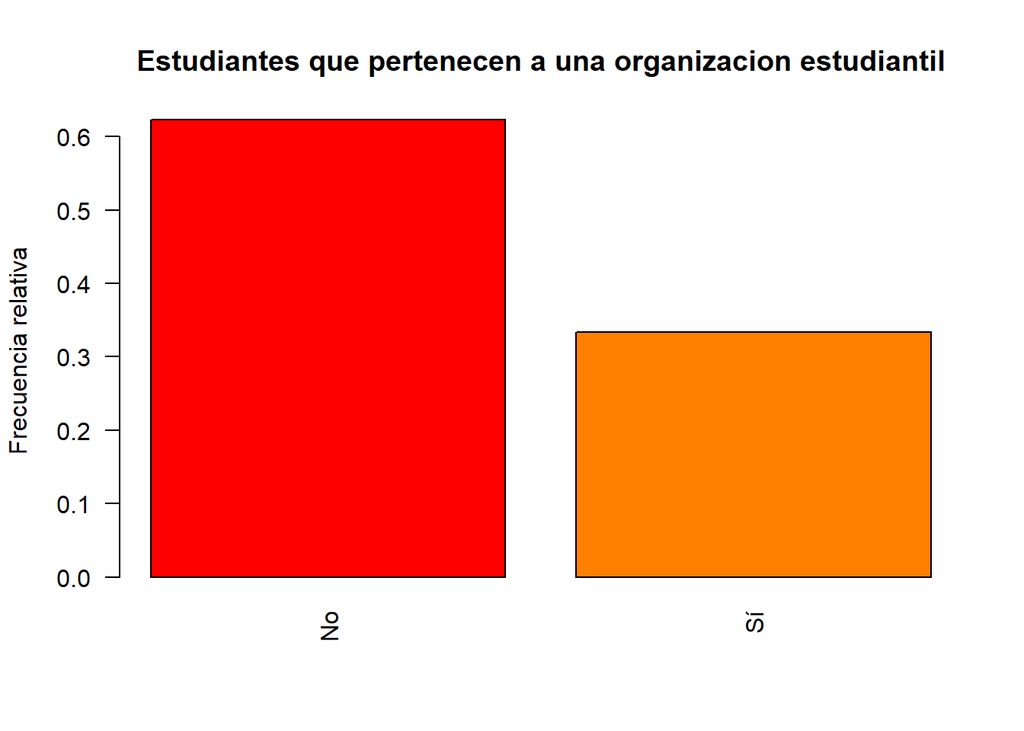

```r
tabla_Org_estudiantil=table(data0$Org_est)
barplot(tabla_Org_estudiantil/nrow(data0),las=2,main="Estudiantes que pertenecen a una organizacion estudiantil", col=rainbow(12), ylab = "Frecuencia relativa")
```

Denota que los estudiantes no son miembros de organizaciones estudiantiles en mayor proporcion

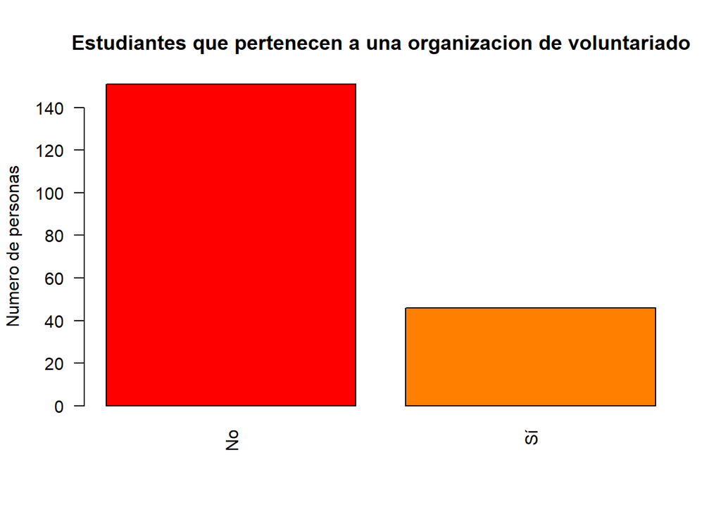

```r
tabla_Voluntariado=table(data0$Voluntariado)
barplot(tabla_Voluntariado,las=2,main="Estudiantes que pertenecen a una organizacion de voluntariado", col=rainbow(12), ylab = "Numero de personas")
```

Denota que los estudiantes no son hacen voluntariado en mayor proporcion

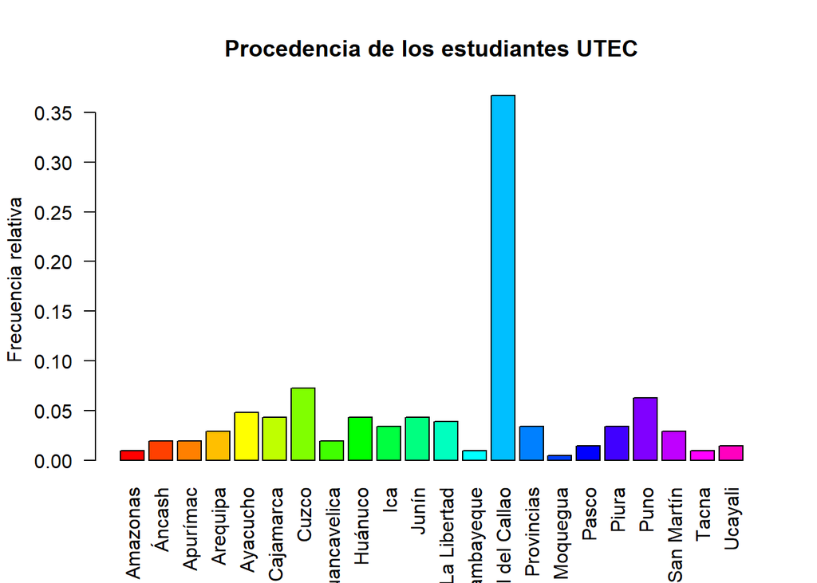

```r
tabla_Procedencia=table(data0$Procedencia)
barplot(tabla_Procedencia/nrow(data0),las=2,main="Procedencia de los estudiantes UTEC", col=rainbow(24), ylab = "Frecuencia relativa")
```

En mayor proporcion los estudiantes provienen del interior del pais

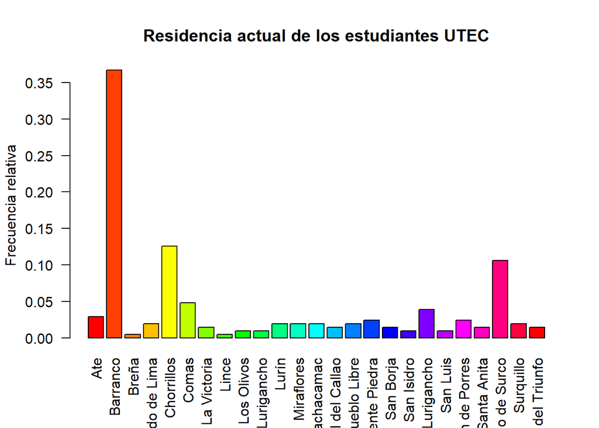

```r
tabla_Residencia=table(data0$Residencia)
barplot(tabla_Residencia/nrow(data0),las=2,main="Residencia actual de los estudiantes UTEC", col=rainbow(24), ylab = "Frecuencia relativa")
```

Denota que en mayor proporcion hay estudiantes residiendo en Barranco, Chorillos y Surco

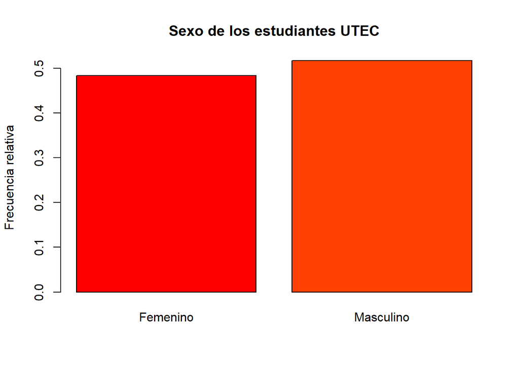

```r
tabla_Sexo=table(data0$Sexo)
barplot(tabla_Sexo/nrow(data0),main="Sexo de los estudiantes UTEC", col=rainbow(24), ylab = "Frecuencia relativa")
```

Denota que la proporcion entre mujeres y varones en utec son similares

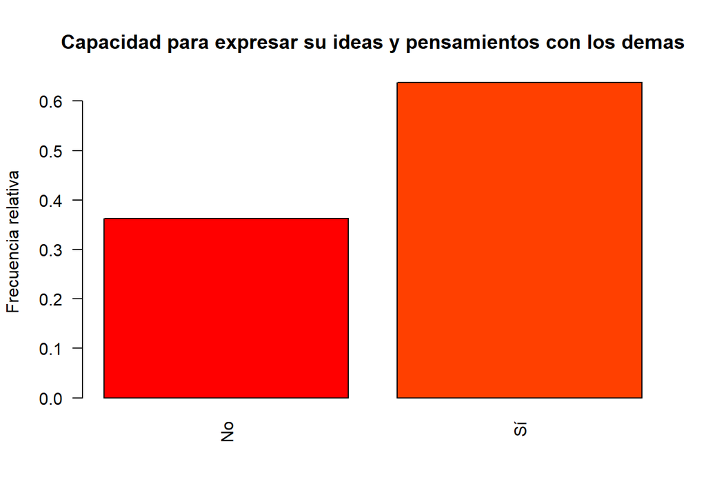

```r
tabla_Sociabilidad=table(data0$Expres_pub)
barplot(tabla_Sociabilidad/nrow(data0),las=2,main="Capacidad para expresar su ideas y pensamientos con los demas", col=rainbow(24), ylab = "Frecuencia relativa")
```

Denota que los si son capaces de expresar sus ideas en mayor proporcion

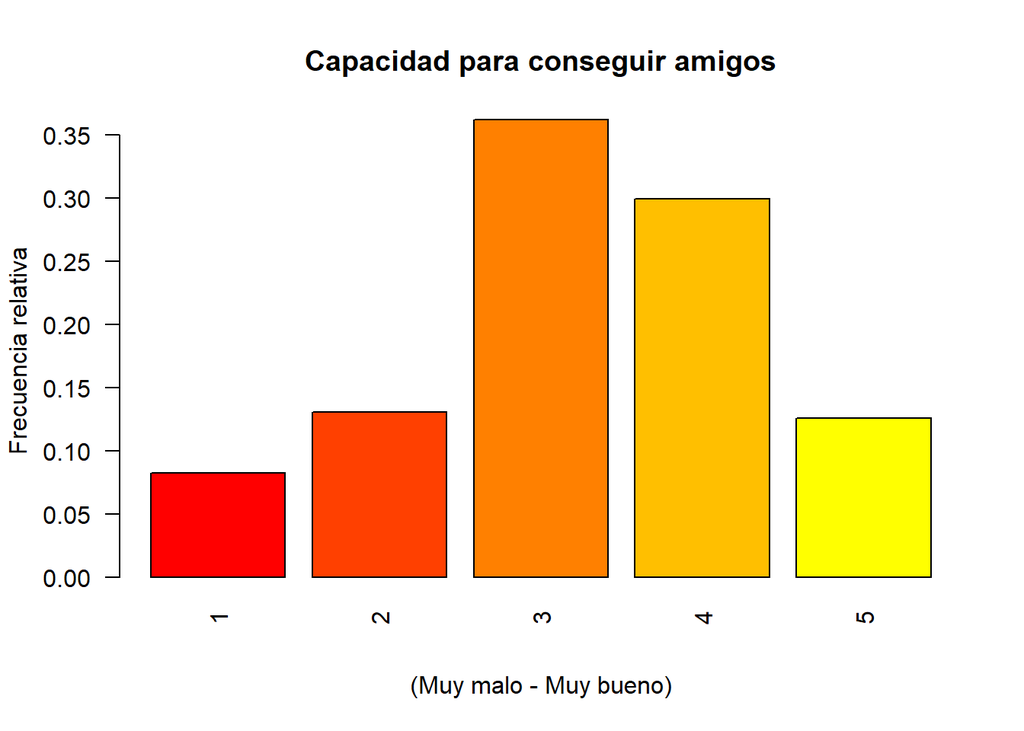

```r
tabla_Amigos=table(data0$Amigos)
barplot(tabla_Amigos/nrow(data0),las=2,main="Capacidad para conseguir amigos", col=rainbow(24), xlab= "(Muy malo - Muy bueno)", ylab = "Frecuencia relativa")
```

Denota que los estudiantes no son ni buenos ni malos consiguiendo amigos, esto contrasta con lo anterior

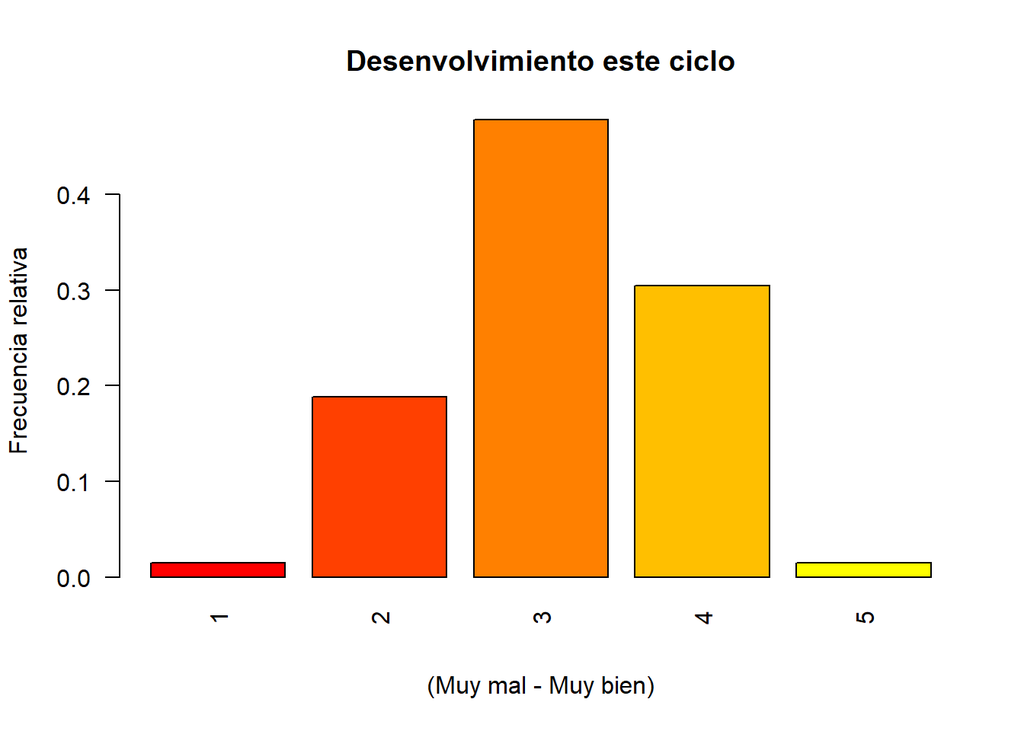

```r
tabla_Autoeval=table(data0$Autoeval)
barplot(tabla_Autoeval/nrow(data0),las=2,main="Desenvolvimiento este ciclo", col=rainbow(24), xlab= "(Muy mal - Muy bien)", ylab = "Frecuencia relativa")
```

Denota que los estudiantes sienten que les va regular en el presente ciclo academico

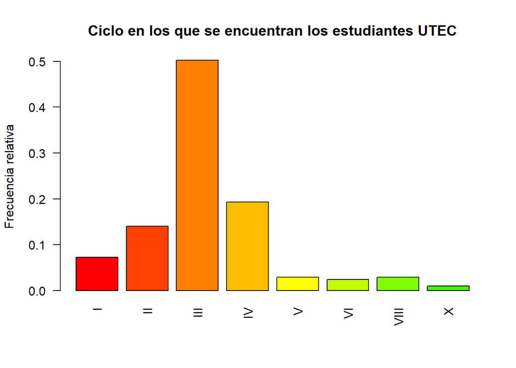

```r
tabla_Ciclo=table(data0$Ciclo)
barplot(tabla_Ciclo/nrow(data0),las=2,main="Ciclo en los que se encuentran los estudiantes UTEC", col=rainbow(24), ylab = "Frecuencia relativa")
```

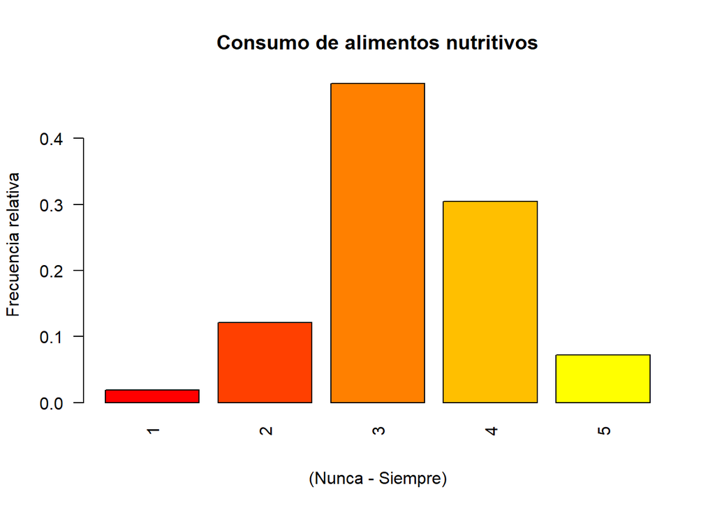

```r
tabla_Alim_nut=table(data0$Alim_nut)
barplot(tabla_Alim_nut/nrow(data0),las=2,main="Consumo de alimentos nutritivos", col=rainbow(24),xlab="(Nunca - Siempre)", ylab = "Frecuencia relativa")
```

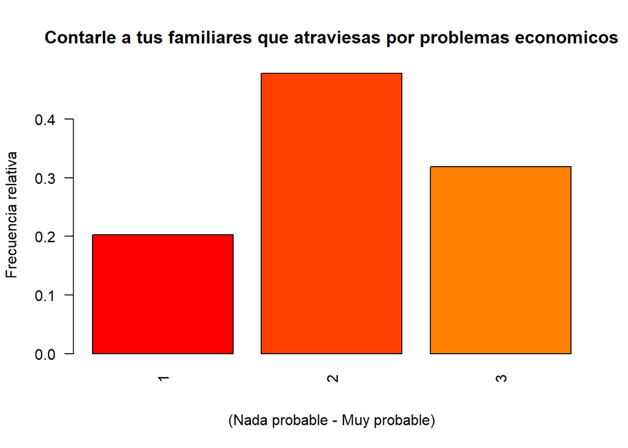

```r
tabla_Prob_Eco=table(data0$Prob_eco)
barplot(tabla_Prob_Eco/nrow(data0),las=2,main="Contarle a tus familiares que atraviesas por problemas economicos", col=rainbow(24),xlab="(Nada probable - Muy probable)", ylab = "Frecuencia relativa")
```

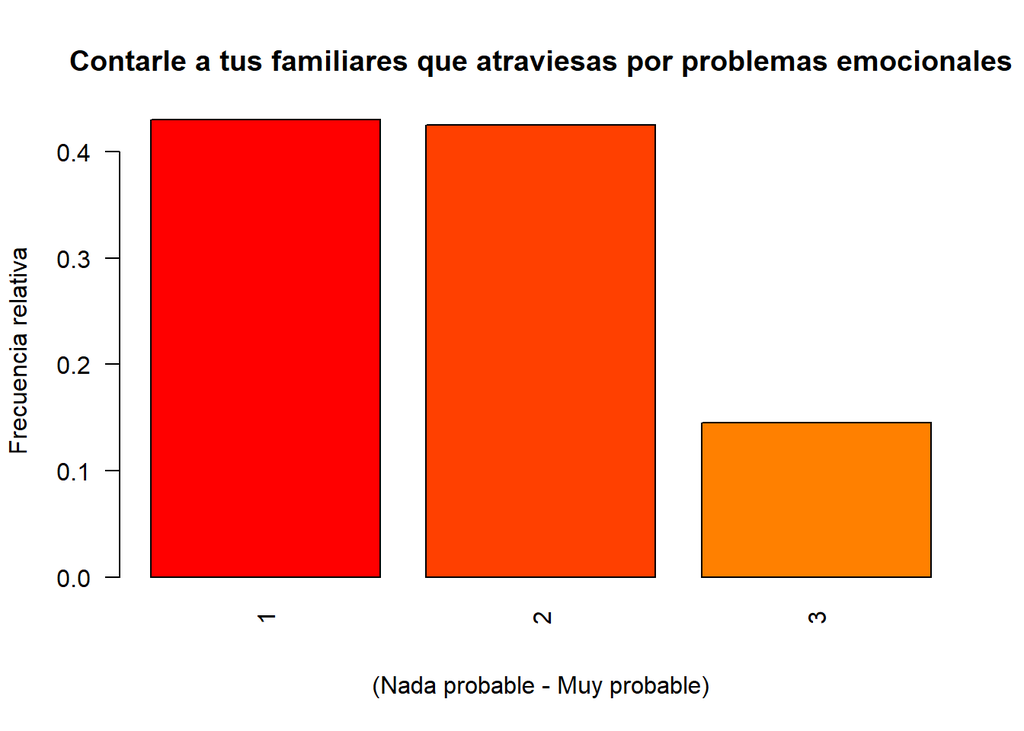

```r
tabla_Prob_emo=table(data0$Prob_emo)
barplot(tabla_Prob_emo/nrow(data0),las=2,main="Contarle a tus familiares que atraviesas por problemas emocionales", col=rainbow(24),xlab="(Nada probable - Muy probable)", ylab = "Frecuencia relativa")
```

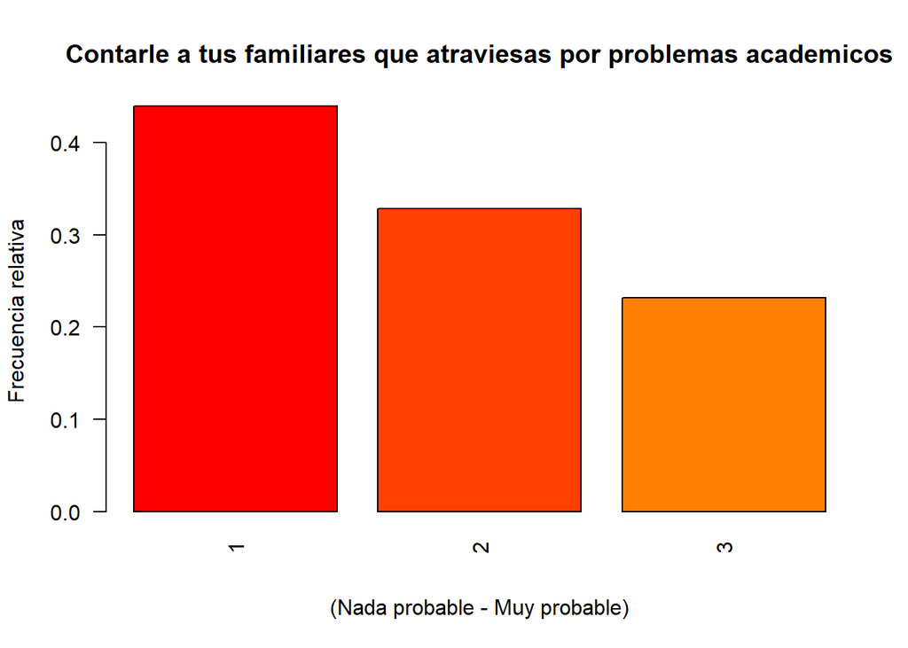

```r
tabla_acad=table(data0$Prob_acad)
barplot(tabla_acad/nrow(data0),las=2,main="Contarle a tus familiares que atraviesas por problemas academicos", col=rainbow(24),xlab="(Nada probable - Muy probable)", ylab = "Frecuencia relativa")
```